# Mediation through different variables

Now that we know that ADHD_DX is related to many of the PRS thresholds, let’s see how different variables mediate the result:

```r
gf = read.csv('~/data/prs/clinical_06192017.csv')
gf = gf[gf$ADHD_current_yes_no!='exclude',]
pgc = read.csv('~/data/prs/PRS2017_original_clump_default.csv')
```

Let’s combine the clinical data and PRS to restrict the size of our matrices:

```r
df = merge(gf, pgc)
# remove duplicated MRNs
df = df[!duplicated(df$MRN),]
```

Now we’re ready to run our LME using family ID as the random term, so we can have an idea of what threshold to use:

```r
library(nlme)
print(sprintf('NV vs ADHD: %d subjects', sum(!is.na(df$ADHD_current_yes_no))))
```

```
[1] "NV vs ADHD: 1003 subjects"
```

```r
# start with quick T-test for DX
vars = which(grepl('^PROFILES', colnames(df)))
all_res = c()
x_str = 'ADHD_current_yes_no'
for (i in 1:length(vars)) {
    y_str = colnames(df)[vars][i]
    fm_str = sprintf('%s ~ %s', y_str, x_str) # make sure the interesting variable comes last!
    fit = try(lme(as.formula(fm_str), random=~1|NuclearFamID, data=df, na.action = na.omit))
    last_row = nrow(summary(fit)$tTable)
    res = c(summary(fit)$tTable[last_row,'t-value'], summary(fit)$tTable[last_row,'p-value'])
    all_res = rbind(all_res, res)
}
colnames(all_res) = c(sprintf('Tstat_%s', x_str), sprintf('pval_%s', x_str))
rownames(all_res) = colnames(df)[vars]
print(all_res)
```

```
                         Tstat_ADHD_current_yes_no pval_ADHD_current_yes_no
PROFILES.0.00001.profile                -1.4374082             0.1514314918
PROFILES.0.00005.profile                -1.0947511             0.2743246269
PROFILES.0.0001.profile                 -1.5388582             0.1246777765
PROFILES.0.0005.profile                 -1.7695812             0.0776052562
PROFILES.0.001.profile                  -0.7841017             0.4334728023
PROFILES.0.005.profile                  -2.0082145             0.0453333433
PROFILES.0.01.profile                   -2.6529553             0.0083163450
PROFILES.0.05.profile                   -3.3747549             0.0008155540
PROFILES.0.1.profile                    -3.1926408             0.0015282041
PROFILES.0.2.profile                    -3.4157249             0.0007053514
PROFILES.0.3.profile                    -3.6465871             0.0003030930
PROFILES.0.4.profile                    -3.6025318             0.0003573476
PROFILES.0.5.profile                    -3.6126580             0.0003441249
```

Let’s go with .3 for now. We’ll try a simple mediation model, using IQ because we know it works:

```r
X = 'PROFILES.0.3.profile'
M = 'IQ'
Y = 'ADHD_current_yes_no'
library(mediation)
neuropsych = read.csv('~/data/prs/neuropsych_07072017.csv')
data = merge(df, neuropsych, by='MRN')
data = data[!is.na(data$IQ), ]
fm = as.formula(sprintf('%s ~ %s', M, X))
fy = as.formula(sprintf('%s ~ %s + %s', Y, X, M))
model.M <- lm(fm, data=data)
model.Y <- glm(fy, data=data, family=binomial(link='logit'))
results <- mediate(model.M, model.Y, treat=X, mediator=M, boot=T, sims=100, boot.ci.type='bca')
summary(results)
```

```
Causal Mediation Analysis

Nonparametric Bootstrap Confidence Intervals with the BCa Method

                         Estimate 95% CI Lower 95% CI Upper p-value
ACME (control)             -0.966       -0.982       -0.727       0
ACME (treated)              0.000           NA           NA       1
ADE (control)              -0.966       -0.982       -0.727       0
ADE (treated)               0.000           NA           NA       1
Total Effect               -0.966       -0.982       -0.727       0
Prop. Mediated (control)    1.000           NA           NA       0
Prop. Mediated (treated)    0.000           NA           NA       1
ACME (average)             -0.483       -0.491       -0.363       0
ADE (average)              -0.483       -0.491       -0.363       0
Prop. Mediated (average)    0.500           NA           NA       0

Sample Size Used: 953


Simulations: 100
```

What are the effects of scaling the variables?

```r
X = 'PROFILES.0.3.profile'
M = 'IQ'
Y = 'ADHD_current_yes_no'
library(mediation)
neuropsych = read.csv('~/data/prs/neuropsych_07072017.csv')
data = merge(df, neuropsych, by='MRN')
data = data[!is.na(data$IQ), ]
data[, c(X, M)] = scale(data[, c(X, M)])
data = as.data.frame(data)
fm = as.formula(sprintf('%s ~ %s', M, X))
fy = as.formula(sprintf('%s ~ %s + %s', Y, X, M))
model.M <- lm(fm, data=data)
model.Y <- glm(fy, data=data, family=binomial(link='logit'))
results <- mediate(model.M, model.Y, treat=X, mediator=M, boot=T, sims=100, boot.ci.type='bca')
summary(results)
```

```
Causal Mediation Analysis

Nonparametric Bootstrap Confidence Intervals with the BCa Method

                         Estimate 95% CI Lower 95% CI Upper p-value
ACME (control)            -0.0193      -0.0273      -0.0120       0
ACME (treated)            -0.0180      -0.0254      -0.0106       0
ADE (control)             -0.0481      -0.0765      -0.0265       0
ADE (treated)             -0.0468      -0.0749      -0.0256       0
Total Effect              -0.0661      -0.0890      -0.0451       0
Prop. Mediated (control)   0.2916       0.1570       0.4693       0
Prop. Mediated (treated)   0.2721       0.1484       0.4551       0
ACME (average)            -0.0186      -0.0264      -0.0118       0
ADE (average)             -0.0475      -0.0757      -0.0260       0
Prop. Mediated (average)   0.2819       0.1574       0.4628       0

Sample Size Used: 953


Simulations: 100
```

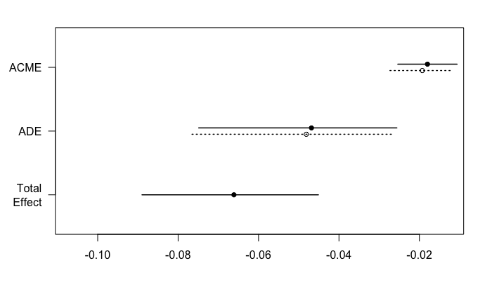

```r
plot(results)
```

These seem to be quite different than the ones without scaling the variables. What’s up?

First, let’s interpret this scaled model, because the numbers seem to make a bit more sense. As we’re using linear models, Total Effect ~ ADE + ACME. This *Total effect* is the effect of X in Y without M (PRS on DX without IQ). The *Direct Effect (ADE)* is the direct effect of X on Y after taking into account a mediation (indirect) effect of M (i.e. direct effect of PRS on DX after taking IQ into account). Finally, the *Average Causal Mediation Effects (ACME)* is the total minus the direct effect. The goal of mediation analysis is to obtain this indirect effect and see if it’s statistically significant, which in our case actually is.

Now, what’s going on with scaling? Maybe it’s because it uses the actual coefficients in the equations. So, if we’re looking at a correlation, the coefficients need to be standardized to match something like R. If X were binary, it wouldn’t matter. In any case, let’s keep on scaling them.

Now, let’s see how it compares to SPSS:

```r
write.csv(data, file='/Volumes/Shaw/prs_mediation/spss_test.csv')
```

```
Run MATRIX procedure:

************** PROCESS Procedure for SPSS Release 2.16.1 *****************

          Written by Andrew F. Hayes, Ph.D.       www.afhayes.com
    Documentation available in Hayes (2013). www.guilford.com/p/hayes3

Model = 4
    Y = ADHDyn
    X = PRSp3
    M = IQ

Sample size
        953

Outcome: IQ

Model Summary
          R       R-sq        MSE          F        df1        df2          p
      .2733      .0747      .9263    76.7582     1.0000   951.0000      .0000

Model
              coeff         se          t          p       LLCI       ULCI
constant      .0000      .0312      .0000     1.0000     -.0612      .0612
PRSp3         .2733      .0312     8.7612      .0000      .2121      .3345

Outcome: ADHDyn

Coding of binary DV for analysis:
    ADHDyn  Analysis
       .00       .00
       .00      1.00

Logistic Regression Summary
       -2LL   Model LL    p-value   McFadden   CoxSnell   Nagelkrk          n
  1217.5486    38.8354      .0000      .0309      .0399      .0545   953.0000

Model
              coeff         se          Z          p       LLCI       ULCI
constant     -.5506      .0687    -8.0088      .0000     -.6854     -.4159
```

[output cut: 8 more lines]

```

Indirect effect of X on Y
       Effect    Boot SE   BootLLCI   BootULCI
IQ     -.0855      .0221     -.1335     -.0466
******************** ANALYSIS NOTES AND WARNINGS *************************

Number of bootstrap samples for bias corrected bootstrap confidence intervals:
     5000

Level of confidence for all confidence intervals in output:
    95.00

NOTE: The TOTAL option is not available when Y is dichotomous.

------ END MATRIX -----
```

The numbers don’t match perfectly, btu at least in overall significance we’re in the same ballpark. Let me try to increase the number of bootstraps:

```r
X = 'PROFILES.0.3.profile'
M = 'IQ'
Y = 'ADHD_current_yes_no'
library(mediation)
neuropsych = read.csv('~/data/prs/neuropsych_07072017.csv')
data = merge(df, neuropsych, by='MRN')
data = data[!is.na(data$IQ), ]
data[, c(X, M)] = scale(data[, c(X, M)])
data = as.data.frame(data)
fm = as.formula(sprintf('%s ~ %s', M, X))
fy = as.formula(sprintf('%s ~ %s + %s', Y, X, M))
model.M <- lm(fm, data=data)
model.Y <- glm(fy, data=data, family=binomial(link='logit'))
results <- mediate(model.M, model.Y, treat=X, mediator=M, boot=T, sims=5000, boot.ci.type='bca')
summary(results)
```

```
Causal Mediation Analysis

Nonparametric Bootstrap Confidence Intervals with the BCa Method

                         Estimate 95% CI Lower 95% CI Upper p-value
ACME (control)           -0.01929     -0.02939     -0.01085       0
ACME (treated)           -0.01801     -0.02801     -0.00999       0
ADE (control)            -0.04816     -0.07865     -0.01791       0
ADE (treated)            -0.04688     -0.07691     -0.01741       0
Total Effect             -0.06617     -0.09399     -0.03768       0
Prop. Mediated (control)  0.29149      0.16600      0.65389       0
Prop. Mediated (treated)  0.27223      0.15073      0.65214       0
ACME (average)           -0.01865     -0.02862     -0.01036       0
ADE (average)            -0.04752     -0.07771     -0.01765       0
Prop. Mediated (average)  0.28186      0.15795      0.65332       0

Sample Size Used: 953


Simulations: 5000
```

```r
summary(model.Y)
```

```
Call:
glm(formula = fy, family = binomial(link = "logit"), data = data)

Deviance Residuals:
    Min       1Q   Median       3Q      Max
-1.5787  -0.9532  -0.8124   1.3014   1.8275

Coefficients:
                     Estimate Std. Error z value Pr(>|z|)
(Intercept)          -0.55060    0.06875  -8.009 1.16e-15 ***
PROFILES.0.3.profile -0.21749    0.07092  -3.066  0.00217 **
IQ                   -0.31268    0.07250  -4.313 1.61e-05 ***
---
Signif. codes:  0 ‘***’ 0.001 ‘**’ 0.01 ‘*’ 0.05 ‘.’ 0.1 ‘ ’ 1

(Dispersion parameter for binomial family taken to be 1)

    Null deviance: 1256.4  on 952  degrees of freedom
Residual deviance: 1217.5  on 950  degrees of freedom
AIC: 1223.5

Number of Fisher Scoring iterations: 4
```

So, this matches quite well. The main differences then are in the calculation of the mediation. But it doesn’t look like the differences are that big anyways.

But the mediation package can also run lmer, even though bootstrap doesn’t work… should we try it?

```r
library(lme4)
X = 'PROFILES.0.3.profile'
M = 'IQ'
Y = 'ADHD_current_yes_no'
library(mediation)
neuropsych = read.csv('~/data/prs/neuropsych_07072017.csv')
data = merge(df, neuropsych, by='MRN')
data = data[!is.na(data$IQ), ]
# here we have to scale otherwise we get some weird warnings
data[, c(X, M)] = scale(data[, c(X, M)])
fm = as.formula(sprintf('%s ~ %s + (1|NuclearFamID)', M, X))
fy = as.formula(sprintf('%s ~ %s + %s + (1|NuclearFamID)', Y, X, M))
model.M <- lmer(fm, data=data)
model.Y <- glmer(fy, data=data, family=binomial(link='probit'))
results <- mediate(model.M, model.Y, treat=X, mediator=M, sims=100)
summary(results)
```

```
Causal Mediation Analysis

Quasi-Bayesian Confidence Intervals

Mediator Groups: NuclearFamID

Outcome Groups: NuclearFamID

Output Based on Overall Averages Across Groups

                         Estimate 95% CI Lower 95% CI Upper p-value
ACME (control)           -0.01841     -0.03160     -0.00850       0
ACME (treated)           -0.01738     -0.02996     -0.00801       0
ADE (control)            -0.04839     -0.07583     -0.01613       0
ADE (treated)            -0.04736     -0.07437     -0.01572       0
Total Effect             -0.06577     -0.09162     -0.03426       0
Prop. Mediated (control)  0.27699      0.13199      0.60126       0
Prop. Mediated (treated)  0.26073      0.11967      0.58967       0
ACME (average)           -0.01789     -0.03078     -0.00826       0
ADE (average)            -0.04787     -0.07510     -0.01593       0
Prop. Mediated (average)  0.26886      0.12602      0.59546       0

Sample Size Used: 953


Simulations: 100
```

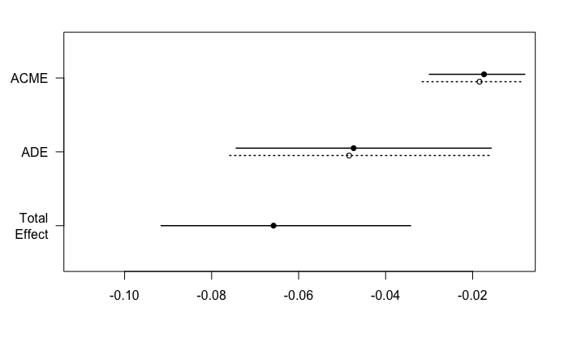

```r
plot(results)
```

The results using mixed-effect models is similar to not using it, which is reassuring. Also, if we use simpler models (i.e. non-mixed), we could also run some functions from the MBESS package, which would allow us to calculate effect sizes for the estimates.

# Checking several different mediators

Now we can have some fun checking several different mediators.

```r
library(mediation)
run_mediation = function(data, X, M, Y, nboot=100, short=T) {
    data = data[!is.na(data[, M]), ]
    data[, c(X, M)] = scale(data[, c(X, M)])
    data = as.data.frame(data)

    fm = as.formula(sprintf('%s ~ %s', M, X))
    fy = as.formula(sprintf('%s ~ %s + %s', Y, X, M))
    model.M <- lm(fm, data=data)
    model.Y <- glm(fy, data=data, family=binomial(link='logit'))
    results <- mediate(model.M, model.Y, treat=X, mediator=M, boot=T, sims=nboot, boot.ci.type='bca')
    if (short) {
      res = c(results$mediator, results$nobs, results$tau.coef, results$tau.p, results$d.avg, results$d.avg.p,
              results$z.avg, results$z.avg.p, results$n.avg, results$n.avg.p)
      names(res) = c('M', 'nobs', 'tot', 'tot_p', 'acme', 'acme_p', 'ade', 'ade_p', 'prop', 'prop_p')
      return(res)
    } else {
      return(results)
    }
}
```

Now we’re ready to try different variables:

```r
neuropsych = read.csv('~/data/prs/neuropsych_07072017.csv')
data = merge(df, neuropsych, by='MRN')
res = c()
for (m in colnames(neuropsych)[2:ncol(neuropsych)]) {
  print(sprintf('Running %s', m))
  res = rbind(res, run_mediation(data, 'PROFILES.0.3.profile', m, 'ADHD_current_yes_no'))
}
```

```
[1] "Running IQ"
[1] "Running SSVM_WJ"
[1] "Running SSDS_WJ"
[1] "Running SS_PS"
[1] "Running RawscoreDSWISC"
[1] "Running RawscoreSSWISC"
[1] "Running SS_berry"
[1] "Running X_of_omissions"
[1] "Running X_commissions"
[1] "Running hit_RT"
[1] "Running hit_RT_SE"
[1] "Running variability_of_SE"
[1] "Running Dprime"
[1] "Running beta"
[1] "Running X_perservations"
[1] "Running hit_RT_block_change"
[1] "Running hit_RT_SE_block_change"
[1] "Running hit_RT_ISI_change"
[1] "Running hit_RT_SE_ISI_change"
[1] "Running FOCUS"
[1] "Running IMPULSIVE_RESPONSE"
[1] "Running SUSTAINED_ATTENTION"
[1] "Running VIGILANCE"
```

```r
res = cbind(res, 'neuropsych')
colnames(res)[ncol(res)] = 'dtype'
all_res = res
```

```r
dti = read.csv('~/data/prs/dti_07062017.csv')
data = merge(df, dti, by='MRN')
res = c()
for (m in colnames(dti)[25:ncol(dti)]) {
  print(sprintf('Running %s', m))
  res = rbind(res, run_mediation(data, 'PROFILES.0.3.profile', m, 'ADHD_current_yes_no'))
}
```

```
[1] "Running FA_left_cst"
[1] "Running AD_left_cst"
[1] "Running RD_left_cst"
[1] "Running MO_left_cst"
[1] "Running FA_left_ifo"
[1] "Running AD_left_ifo"
[1] "Running RD_left_ifo"
[1] "Running MO_left_ifo"
[1] "Running FA_left_ilf"
[1] "Running AD_left_ilf"
[1] "Running RD_left_ilf"
[1] "Running MO_left_ilf"
[1] "Running FA_left_slf"
[1] "Running AD_left_slf"
[1] "Running RD_left_slf"
```

[output cut: 29 more lines]

```r
res = cbind(res, 'dti')
colnames(res)[ncol(res)] = 'dtype'
all_res = rbind(all_res, res)
```

```r
struct = read.csv('~/data/prs/struct_07072017_v3.csv')
data = merge(df, struct, by='MRN')
res = c()
for (m in colnames(struct)[11:ncol(struct)]) {
  print(sprintf('Running %s', m))
  res = rbind(res, run_mediation(data, 'PROFILES.0.3.profile', m, 'ADHD_current_yes_no'))
}
```

```
[1] "Running lh_bankssts_area"
[1] "Running lh_caudalanteriorcingulate_area"
[1] "Running lh_caudalmiddlefrontal_area"
[1] "Running lh_cuneus_area"
[1] "Running lh_entorhinal_area"
[1] "Running lh_fusiform_area"
[1] "Running lh_inferiorparietal_area"
[1] "Running lh_inferiortemporal_area"
[1] "Running lh_isthmuscingulate_area"
[1] "Running lh_lateraloccipital_area"
[1] "Running lh_lateralorbitofrontal_area"
[1] "Running lh_lingual_area"
[1] "Running lh_medialorbitofrontal_area"
[1] "Running lh_middletemporal_area"
[1] "Running lh_parahippocampal_area"
```

[output cut: 255 more lines]

```r
res = cbind(res, 'struct')
colnames(res)[ncol(res)] = 'dtype'
all_res = rbind(all_res, res)
```